# Praca domowa 1

Przemysław Chojecki

8 03 2020

```r
cards <- read.csv("german_credit_data_weka_dataset.csv")
```

## Niemieckie dane bankowe

Dane zawierają informacje o użytkownikach systemu bankowego. Poza podstawowymi jak wiek, zarobki, kredyty i ich cele i wielkości najważniejszą kolumną jest `customer_type`, która jest przewidzianą zdolnością kredytową rozumianą binarnie: “dobra” i “zła”. Ta kolumna jest naszym targetem.  
Przyjrzyjmy się tym danym.

```r
head(cards, 3)
```

```
##   checking_account_status duration credit_history purpose credit_amount savings
## 1                     A11        6            A34     A43          1169     A65
## 2                     A12       48            A32     A43          5951     A61
## 3                     A14       12            A34     A46          2096     A61
##   present_employment installment_rate personal other_debtors present_residence
## 1                A75                4      A93          A101                 4
## 2                A73                2      A92          A101                 2
## 3                A74                2      A93          A101                 3
##   property age other_installment_plans housing existing_credits  job dependents
## 1     A121  67                    A143    A152                2 A173          1
## 2     A121  22                    A143    A152                1 A173          1
## 3     A121  49                    A143    A152                1 A172          2
##   telephone foreign_worker customer_type
## 1      A192           A201             1
## 2      A191           A201             2
## 3      A191           A201             1
```

```r
summary(cards)
```

```
##  checking_account_status    duration    credit_history    purpose
##  A11:274                 Min.   : 4.0   A30: 40        A43    :280
##  A12:269                 1st Qu.:12.0   A31: 49        A40    :234
##  A13: 63                 Median :18.0   A32:530        A42    :181
##  A14:394                 Mean   :20.9   A33: 88        A41    :103
##                          3rd Qu.:24.0   A34:293        A49    : 97
##                          Max.   :72.0                  A46    : 50
##                                                        (Other): 55
##  credit_amount   savings   present_employment installment_rate personal
##  Min.   :  250   A61:603   A71: 62            Min.   :1.000    A91: 50
##  1st Qu.: 1366   A62:103   A72:172            1st Qu.:2.000    A92:310
##  Median : 2320   A63: 63   A73:339            Median :3.000    A93:548
##  Mean   : 3271   A64: 48   A74:174            Mean   :2.973    A94: 92
##  3rd Qu.: 3972   A65:183   A75:253            3rd Qu.:4.000
##  Max.   :18424                                Max.   :4.000
##
##  other_debtors present_residence property        age
##  A101:907      Min.   :1.000     A121:282   Min.   :19.00
##  A102: 41      1st Qu.:2.000     A122:232   1st Qu.:27.00
##  A103: 52      Median :3.000     A123:332   Median :33.00
##                Mean   :2.845     A124:154   Mean   :35.55
##                3rd Qu.:4.000                3rd Qu.:42.00
##                Max.   :4.000                Max.   :75.00
##
##  other_installment_plans housing    existing_credits   job        dependents
##  A141:139                A151:179   Min.   :1.000    A171: 22   Min.   :1.000
##  A142: 47                A152:713   1st Qu.:1.000    A172:200   1st Qu.:1.000
##  A143:814                A153:108   Median :1.000    A173:630   Median :1.000
##                                     Mean   :1.407    A174:148   Mean   :1.155
##                                     3rd Qu.:2.000               3rd Qu.:1.000
##                                     Max.   :4.000               Max.   :2.000
##
##  telephone  foreign_worker customer_type
##  A191:596   A201:963       Min.   :1.0
##  A192:404   A202: 37       1st Qu.:1.0
##                            Median :1.0
##                            Mean   :1.3
##                            3rd Qu.:2.0
##                            Max.   :2.0
##
```

Widzimy, że na szczęście nie posiadamy tutaj żadnych braków danych. To dobrze, dzięki temu nie musimy ich sztucznie uzupełniać.  
Są też negatywne wiadomości. Wiele z kolumn jest typu `factor`, a to znaczy, że w czasie przyszłej analizy, a potem modelowania każdy z nich zamieni się na wiele kolumn.

## Kilka ciekawych zaleznosci

Jak rozkłada się wiek w ramach dobrej/złej zdolności kredytowej.

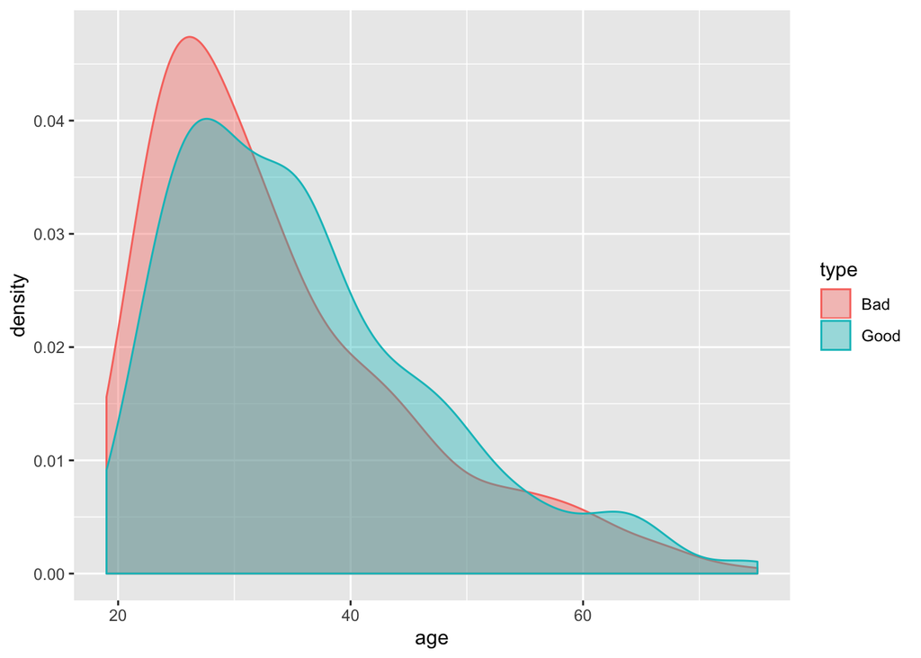

Możemy wnioskować, że różnice są niewielkie w poszczególnych grupach i raczej wiek na zdolność kredytową ma mały wpływ.

Jak rozklada się długość kredytu w grupach zdolności kredytowej.

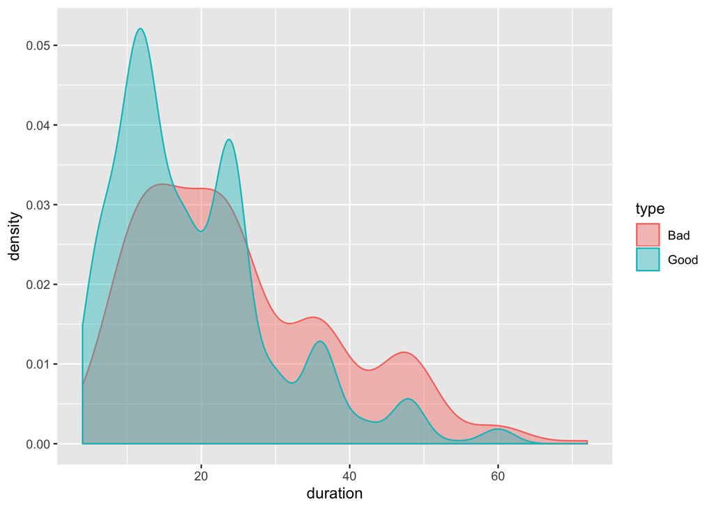

```r
data <- cbind(cards$duration, cards$customer_type) %>% data.frame
colnames(data) <- c("duration", "type")
data$type <- ifelse(data$type==1, "Good", "Bad")
data %>%
  ggplot(aes(x=duration, color = type)) +
  geom_density(alpha=0.4, aes(fill=type))
```

Tutaj widzimy zdecydowaną przewagę krórkookresowych kredytów w grupie wysoko ocenianych kredytobiorców.

Jak rozklada się wielkość pożyczki w grupach zdolności kredytowej.

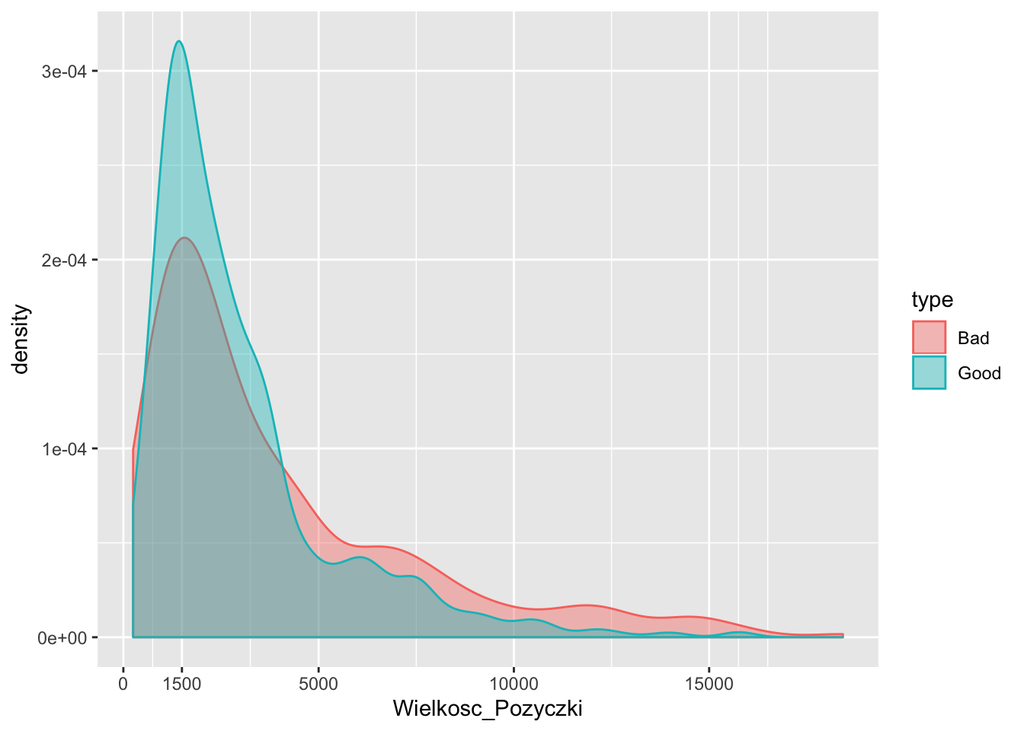

```r
data <- cbind(cards$credit_amount, cards$customer_type) %>% data.frame
colnames(data) <- c("Wielkosc_Pozyczki", "type")
data$type <- ifelse(data$type==1, "Good", "Bad")
data %>%
  ggplot(aes(x=Wielkosc_Pozyczki, color = type)) +
  geom_density(alpha=0.4, aes(fill=type)) +
  scale_x_continuous(breaks=c(0, 1500, 5000, 10000, 15000))
```

Małe pożyczki są OK, ale kredytobiorcy większych pożyczek są gorzej oceniani. Być może więkrze pożyczki są częściej niespacane?

Jak dużo jest pożyczek odpowiedniej wielkości (w sumie).

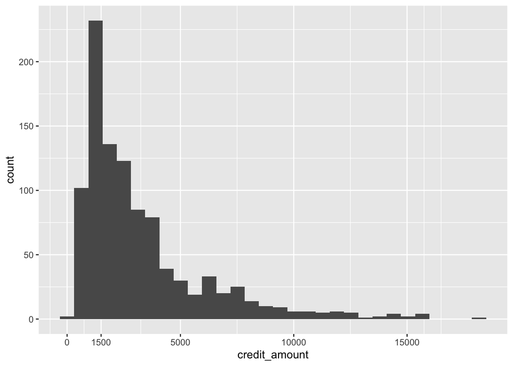

```r
ggplot(cards) +
  geom_histogram(aes(x=credit_amount)) +
  scale_x_continuous(breaks=c(0, 1500, 5000, 10000, 15000))
```

Jest bardzo duża liczba małych pożyczek co może powodować problemy w uczeniu i późniejszym przewidywaniu dla dużych.

## Narzedzie `DataExplorer`

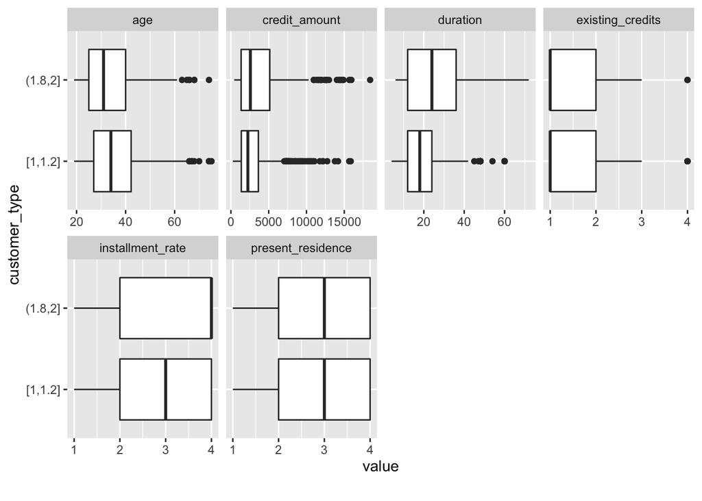

```r
plot_boxplot(cards, by = "customer_type")
```

Na tym wykresie możemy zauważyć, że różnice między grupami zdolności kredytowej są przede wszystkim na kolumnach `credit_amount` oraz `duration`, gdzie użytkownicy ze słabą zdolnością kredytową mają większą wariancję. Teoretycznie możenmy zauważyć różnice na boxplocie `installment_rate`, ale nie uznałbym jej z góry za istotną, gdyż jest to różnica tylko w medianie. Jednakże z kontekstu możemy się domyślać, że kolumna ta może mieć wpływ na zdolność kredytową. Przyjrzyjmy się więc jej bliżej.

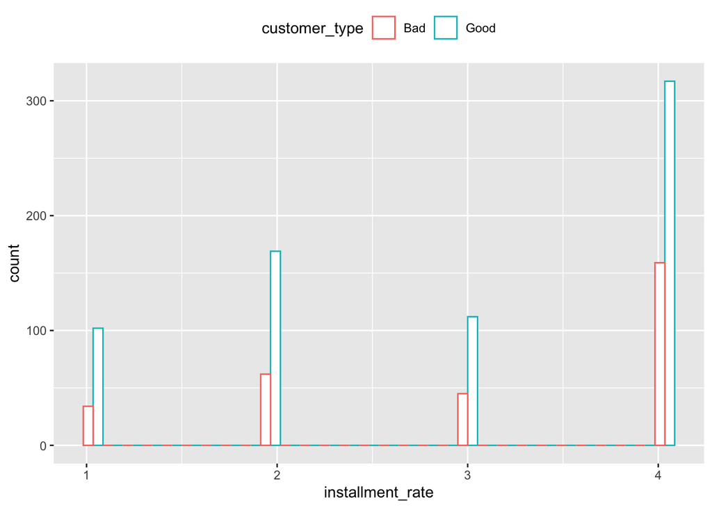

```r
tmp <- cards
tmp$customer_type <- ifelse(tmp$customer_type==1, "Good", "Bad")
ggplot(tmp, aes(x=installment_rate, color=customer_type)) +
  geom_histogram(fill="white", position="dodge")+
  theme(legend.position="top")
```

Na tym dokładniejszym wykresie widzimy, że jednak niema większej zależności między tymi zmiennymi. Są podoble ilorazowo wielkości w kazdej z nich.

### Korelacja

Gdybyśmy naiwnie wykonali korelację(tak jak robi to narzędzie do automatycznych raportów) obrazek byłby nieczytelny:

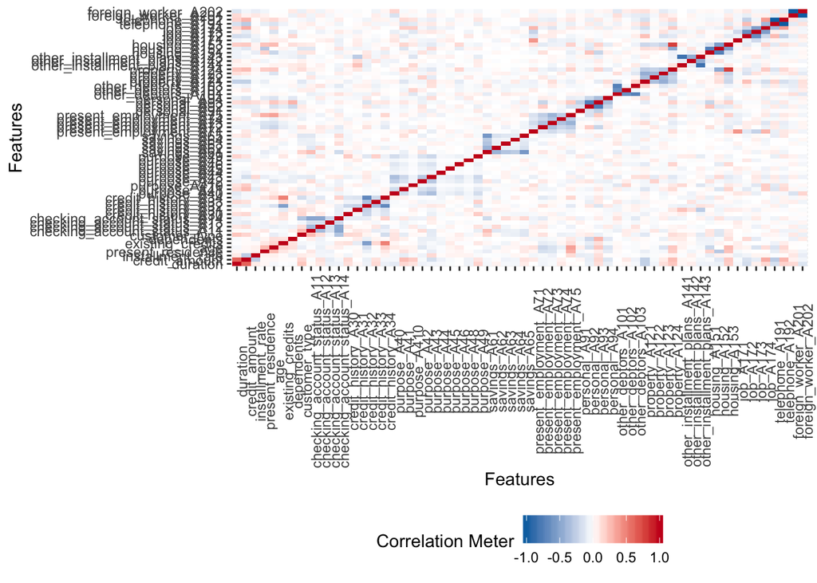

```r
plot_correlation(cards)
```

Co jest spowodowane dużą ilością zmiennych typu `factor` i każdorazowo zamienianych na taką ilość kolumn, ile jest różnych rodzai faktora. Niestety, ręczna zamiana `factor`ów na liczby również jest bez sensu, gdyż z korelacja bierze mniej pod uwagę różnicę w danych między $1$, a $2$ , niż różnicę między $1$, a $3$. Dletego jedynym wyjściem w tej sytuacji jest pozbycie się paru kolumn, lub zainwestowanie w większy monitor.

### Automatyczny raport

```r
create_report(cards, config = configure_report(add_introduce = FALSE,
                                               add_plot_intro = FALSE,
                                               add_plot_str = FALSE,
                                               add_plot_missing = FALSE,
                                               add_plot_histogram = FALSE,
                                               add_plot_density = TRUE,
                                               add_plot_qq = FALSE,
                                               add_plot_bar = TRUE,
                                               add_plot_correlation = FALSE,
                                               add_plot_prcomp = FALSE,
                                               add_plot_boxplot = TRUE,
                                               add_plot_scatterplot = TRUE,
                                               plot_density_args = list(geom_density_args = list(alpha=0.4, aes = aes(fill=customer_type, color = customer_type)))))
```

Ten nie wiem czemu, ale nie działa:

```r
create_report(cards, config = configure_report(add_introduce = FALSE,
                                               add_plot_intro = FALSE,
                                               add_plot_str = FALSE,
                                               add_plot_missing = FALSE,
                                               add_plot_histogram = FALSE,
                                               add_plot_density = TRUE,
                                               add_plot_qq = FALSE,
                                               add_plot_bar = TRUE,
                                               add_plot_correlation = FALSE,
                                               add_plot_prcomp = FALSE,
                                               add_plot_boxplot = TRUE,
                                               add_plot_scatterplot = TRUE,
                                               plot_density_args = list(geom_density_args = list(alpha=0.4, aes = aes(fill=customer_type, color = customer_type))),
                                               plot_boxplot_args = list(by = "customer_type")))
```

#### Problemy automatycznego raportu

Idea bardzo fajna i dużo customizacji, jednak wciąż za mało, żeby zastąpić standardowe ploty. Na przykład nie mogłem dodać argumentu do boxplota(tak jak napisałem wyżej). Poza tym nie mogę zmieniać ramki danych do poszczególnych plotów, co jest zrozumiałe, lecz mimo wszystko taka opcja jest przydatna na przykłąd do zrobienia macierzy korelacji dla czytelności na mniejszej ilości kolumn, która wygenerowana przez automatyczny raport jest po prostu nieczytelna z powodu zbyt dużej ich ilości.